[figure not shown]

# Assignment 2.1 Logistic Regression (14 points total)

## Instructions

The graded portion of Assignment 2 consists of one notebook:

```
ps2_nb1.ipynb (v2)
```

There are also ungraded tutorials on pandas and matplotlib that are recommended:.

```
t2-pandas_introduction.ipynb
t3-matplotlib_introduction.ipynb
```

As before, each notebook is designed for cells to be run sequentially.

### Due Dates

- 09.FEB.2022 before 23:59:59 (CET)

### Instructor

- Prof. Dr. Gregory Wheeler (g.wheeler@fs.de)

### Declare your collaborators

You may work alone or in a group. The maximum group size is 4 people.

If you work in a group, use the next cell to enter the list of names (first, last) of your collaborators.

```
# Example
COLLABORATORS = ['Stu Dent', 'May Bee', 'Ki Val Storr']
```

You should also familiarize yourself with the collaboration policy on the course Canvas page.

```python
# Be sure your names are strings
COLLABORATORS = ['Sophie Merl', 'Nicolas Kepper']
```

# Logistic Regression with Two Features

Suppose your task is to predict the solvency of a firm based on two financial indicators: the firm's *return on equity* and the firm's *current ratio*. **Return on Equity** (ROE) is a financial indicator which measures how much profit a firm generates with the equity invested by its shareholders. A positive value is good, whereas a negative value is bad. **Current ratio** is a liquidity measure that measures the firm's ability to pay near-term financial obligations. A negative value may indicate that net working capital is negative, whereas positive values are good.

### Your Task

- **Part A**: Your task is to build a logistic regression classification model that estimates the probability that a firm is **insolvent** ($y = 1$) or **solvent** ($y=0$) based on the features **ROE** and **Current Ratio**. The (artificial) data set you are working with has unusually high variance in both ROE and current ratio, approximating what one might find for young technology firms or start ups. That said, don't get hung up on the cover story for this data set.
- **Part B**: Use the Sklearn to build a logistic regression classifier to perform some analysis.

To begin, run the next cell to import libraries you will need.

```python
import numpy as np
import pandas as pd
import matplotlib.pyplot as plt
```

# PART A - Build a Logistic Regression Classifier

## I. Data preparation

Start by inspecting the dataset `ps2_data-1.csv` in the data folder. Notice that if you try to load this data as a numpy array, using for example

```
data = np.loadtxt('ps2_data-1.csv', delimiter = ',')
```

you will see an error. Why?

```python
# Try np.loadtext here, but be sure to clear away the error before submitting!
```

If you inspect this file you will find that it has column names, which are strings, and numerical data. So, numpy will complain that strings cannot be converted to numerical values. The issue is that **numpy arrays** are tables of values, all of which must be the **same data type**. What this error message is telling you, therefore, is that you are attempting to load a table with two different data types: in this case, strings and numbers.

What should you do? One option is to open up a text editor and remove the column names. But removing these names would require you, rather than the machine, to keep track of the column labels. That isn't a very good option, particularly when you haven't even inspected the data! And trouble compounds with larger datasets.

Fortunately there is a Python package, called **pandas**, designed to work with this particular kind of "mixed-type" rectangular data structure. Specifically, a **data frame** is a two-dimensional, labeled dataset. Data frames are ubiquitous, since most data includes labels of some kind to describe each feature (column) and, sometimes, each example (row). A lot of financial data is in this format, too, particularly **time series** data. The pandas library offers a very powerful toolkit for working with dataframes.

A better solution to our problem then is to load our `ps2_data-1.csv` into a pandas dataframe. The following line of code does this,

```
df = pd.read_csv('ps2_data-1.csv')
```

where `df` is a common naming convention for variables storing dataframes. To inspect `df`, you may type `df.head(5)` to return the labels and first 5 examples:

[figure not shown]

Use the next cell to load your data frame and inspect it.

```python
df = pd.read_csv('ps2_data-1.csv')
df
```

|  | label | x1 | x2 |
| --- | --- | --- | --- |
| 0 | 0 | 0.655965 | -1.063205 |
| 1 | 1 | -7.084630 | 2.034800 |
| 2 | 1 | -2.420879 | -2.639450 |
| 3 | 1 | -4.278147 | -0.410740 |
| 4 | 0 | -1.081851 | 3.804022 |
| ... | ... | ... | ... |
| 348 | 1 | -3.928345 | 1.549502 |
| 349 | 0 | 3.026815 | 1.187822 |
| 350 | 1 | -5.031014 | 1.091927 |
| 351 | 1 | -7.472950 | -1.892655 |
| 352 | 0 | -5.690239 | 1.927723 |

353 rows × 3 columns

Now that we can see our data frame, we discover that it is not quite arranged the way we would like. First, the column labels need to be changed to reflect the category of the taget variable and the correct names of the two features. That is, you need to

```
change: 'label' to 'Insolvent'
        'x1' to 'ROE'
        'x2' to 'Current_Ratio'
```

Note the underscore in the string 'Current_Ratio'. This will be important to allow all key valuse to be indexed later.

The second change that is necessary is to move the target vector, the `Insolvent` column, to the end of the dataframe. The result of these changes should be such that `df.head(5)` returns a dataframe that looks exactly like this:

[figure not shown]

**Your task:**

In the next cell is a partially completed function, `config_df()`, within which you should include a few short lines of code to perform these changes. (By a few, I mean less than 6). When `config_df()` is called, the file `ps2_data-1.csv` is loaded and assigned to `df`, just as you've done above. The dataframe `df` is then changed according to the specifications above. When finished, a series of test cells will call `config_df()` to check that you've done this correctly.

**Student's answer(Top)**

```python
def config_df():
    """
        config_df() is a function to specifically load
        and reconfigure the dataset for this assignment.

        The function takes no argument, but will load the
        data file and reconfigure it each time it is run.

        The output should be a pandas dataframe assigned to
        the variable 'df'
    """
    # load original dataset
    df = pd.read_csv('ps2_data-1.csv')
    df.rename(columns={'label': 'Insolvent', 'x1': 'ROE', 'x2': 'Current_Ratio'}, inplace=True)
    df = df[['ROE', 'Current_Ratio', 'Insolvent']]
    return df
```

**Grade cell: `reconfig_df-test-1` Score: 0.5 / 0.5 (Top)**

```python
# Public Test Cell
# call config_df() to instantiate your dataframe df
df = config_df()
# Test whether 'Insolvent' heading was moved to the last column
assert df.columns[2] == 'Insolvent'
# Additional tests are hidden
### BEGIN HIDDEN TESTS
assert df.columns[1] == 'Current_Ratio'
assert df.columns[0] == 'ROE'
### END HIDDEN TESTS
```

**Grade cell: `reconfig_df-test-2` Score: 0.5 / 0.5 (Top)**

```python
# Test Cell
### BEGIN HIDDEN TESTS
assert round(df['ROE'][25],6) == 3.5216
### END HIDDEN TESTS
```

**Grade cell: `reconfig_df-test-3` Score: 0.5 / 0.5 (Top)**

```python
# Test Cell
### BEGIN HIDDEN TESTS
assert round(df['Current_Ratio'][25],6) == 4.217977
### END HIDDEN TESTS
```

**Grade cell: `reconfig_df-test-4` Score: 0.5 / 0.5 (Top)**

```python
# Test Cell
### BEGIN HIDDEN TESTS
assert round(df['Insolvent'][25],1) == 0
### END HIDDEN TESTS
```

### Dataframes and arrays

Some operations are easier on arrays, others on dataframes. Therefore, it can be helpful to pull the table values out of a dataframe and save them as a numpy array. Indeed, for this assignment, it may turn out to be a bit easier to work with arrays. In any case, the point is to feel comfortable switching when *you* think it might be easier.

This line

```
data = df.values
```

creates a numpy array. Using this hint, complete the next function to extract a $(m \times n-1)$-features matrix `X` and a target vector `y` from an $n$-column dataframe. Note that your function should work for data frames that have other than $(n -1) = 2$ features.

**Student's answer(Top)**

```python
def array_maker(df):
    """
       The function array_maker takes an n-column dataframe
       df, with m rows, and returns:

         X, a (m x n-1) feature matrix
         y, a column vector

       You should assume that the dataframe is arranged where the last
       column is the target variable, y.
    """
    X = df.iloc[:,:-1].values
    y = df.iloc[:,-1:].values.reshape(len(df.iloc[:,-1:].values),)
    return X, y
```

**Grade cell: `array_maker-test-1` Score: 0.25 / 0.25 (Top)**

```python
# Public Test Cell
# call array_maker()
X, y = array_maker(df)
assert y[37] == 1.0
### BEGIN HIDDEN TESTS
X28, _ = array_maker(df)
assert round(X28[37,0],6) == -7.308068
assert round(X28[134,1],6) == 3.065355
assert len(X28) == 353
del X28
### END HIDDEN TESTS
```

**Grade cell: `array-maker-test-2` Score: 0.75 / 0.75 (Top)**

```python
# Test Cell
### BEGIN HIDDEN TESTS
dataf = [{'a': -1.1, 'b': 2.05, 'c': 3.012, 'd': 1},{'a': 5.1, 'b': -.05, 'c': 2.104, 'd': 0},{'a': -0.1, 'b': -2, 'c': 4.0364, 'd': 1}]
ddf = pd.DataFrame(dataf)
Xs, ys = array_maker(ddf)
assert ys[1] == 0.0
assert Xs[2,2] == 4.0364
del ddf
del dataf
del Xs
del ys
### END HIDDEN TESTS
```

## II. Data Visualization

The following block of code includes hints for how to produce a basic scatterplot with a legend that codes which firms in the data set are insolvent and which are solvent.

```
mask = y.flatten() == 1
insolv = plt.scatter(X[mask][:,0], X[mask][:,1])
solv = plt.scatter(X[~mask][:,0], X[~mask][:,1])
```

If you inspect `mask`, you will see that it is an np.array of [Booleans](https://docs.python.org/3/library/stdtypes.html), which is a data type we haven't used yet. What this line does is convert the 0s and 1s in the target vector `y` to `False` and `True`, respectively. Then, `mask`, the stored array of the Boolean encodings of the class labels, is used as a key to find all of the insolvent ($y =1$) firms in our data set, and `~mask` (where `~` acts as logical negation and flips all the truth values in `mask`) is used to pick out all of the solvent firms ($y=0$). `Legend` then takes the saved keys, `insolv` and `solv`, and associates with each the labels 'Insolvent' and 'Solvent', respectively. The color scheme is chosen by default, but naturally you could control that, too, if you liked.

Here is an image of the top half of what your plot should look like:

[figure not shown]

The following block is a *graded cell* reserved for your plot.

**Student's answer Score: 0.25 / 0.25 (Top)**

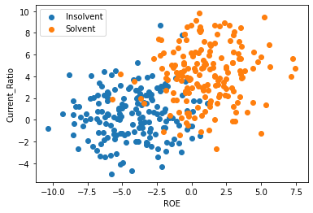

```python
# Plot your data here to receive credit.
mask = y.flatten() == 1
insolv = plt.scatter(X[mask][:,0], X[mask][:,1], label='Insolvent')
solv = plt.scatter(X[~mask][:,0], X[~mask][:,1], label='Solvent')
plt.legend(loc='best')
plt.ylabel('Current_Ratio')
plt.xlabel('ROE')
plt.show()
```

## III. Building a Logistic Regression Model

We turn now to construct a logistic regression classifier. One goal of this exercise is to draw attention to the differences between the hypothesis and cost function for logistic regression and the hypothesis and cost function of linear regression, yet to see that both learning algorithms follow the same basic logic.

### Sigmoid Function

Recall that the *form* of the hypothesis $h(x; \boldsymbol{\theta})$ for logistic regression is

$$h(x; \boldsymbol{\theta}) = g(\boldsymbol{\theta}^Tx)$$

where the function $g$ is the **sigmoid function**:

$$g(z) = \frac{1}{1+e^{-z}}$$

Next, using the `np.exp()` function from numpy, implement the sigmoid function.

**Student's answer(Top)**

```python
def sigmoid(z):
    """implementation of the sigmoid function,
    which takes input z, a positive or negative
    real number, and returns a value between
    0 and 1.

    Your one line of code should be of
    the form:  gz = ---

    """
    # complete sigmoid with one line:
    #
    # gz = ----
    #
    gz = 1 / (1 + np.exp(-z))
    return gz
```

**Grade cell: `sigmoid-fn-test` Score: 0.5 / 0.5 (Top)**

```python
# Public Test
assert sigmoid(0) == 0.5
assert round(sigmoid(.5),5) == 0.62246
### BEGIN HIDDEN TESTS
assert round(sigmoid(-1.3), 7) == 0.214165
assert round(sigmoid(2),7) == 0.8807971
### END HIDDEN TESTS
```

In addition to the public test cell above, you might like to plot your sigmoid function. Use the [numpy.linspace](https://docs.scipy.org/doc/numpy/reference/generated/numpy.linspace.html) function to construct a sample `xx` of 100 evenly spaced numbers between -10 and 10 to feed to your sigmoid function. This can be done easily with the following few lines:

```
xx = np.linspace(-10,10,100)
plt.plot(xx, sigmoid(xx))
plt.xlabel(r'$x$')
plt.ylabel(r'$g(x)$')
plt.grid(True)
```

Constructing this plot is optional. But, it should look something like this:

[figure not shown]

The color and style of your plot might be slightly different.

## Question 1

Suppose you have trained a logistic regression classifier on data $X$ and it outputs on a new example $x$, which is not in your training data $X$, a prediction that $h(x; \boldsymbol{\theta}) = 0.25$.

Identify the true statement(s):

- A) According to your classifier, $p(y = 0 \mid x, \theta) = 0.25$
- B) According to your classifier, $p(y = 0 \mid x, \theta) = 0.75$
- C) According to your classifier, $p(x = 1 \mid y, \theta) = 0.25$
- D) According to your classifier, $p(x = 1 \mid y, \theta) = 0.75$
- E) None of the above are true

Complete the next function with a list recording your answer(s).

### Q1 Answer:

**Student's answer(Top)**

```python
def ans_one():
    # # To answer, set the variable
    #
    # ans = ---
    #
    # to a LIST which is a sublist of
    # the possible answers: ['A', 'B', 'C', 'D', 'E'].
    #
    # Assumption: Data X is the same df we just created and y is the according output.
    ans = ['B']
    return ans
```

**Grade cell: `Question-1-test` Score: 0.5 / 0.5 (Top)**

```python
# Test cell to check the format of your answer
ans = ans_one()
%run -i 'ans_format_test.py'
### BEGIN HIDDEN TESTS
ans = [x.upper() for x in ans]
assert ('B' in ans and len(ans) == 1)
del ans
### END HIDDEN TESTS
```

### Cost Function J$(\theta)$

The cost function for logistic regression is

$$J(\theta) = \frac{1}{m}\sum_{i=1}^{m} \left(-y^{(i)} \log\left[h(x^{(i)}, \boldsymbol{\theta})\right] - (1- y^{(i)}) \log\left[1- h(x^{(i)}, \boldsymbol{\theta}) \right]\right)$$

which can be rewritten as

$$J(\theta) = - \frac{1}{m} \left(\sum_{i=1}^{m} y^{(i)} \log\left[ h(x^{(i)}, \boldsymbol{\theta}) \right] + (1- y^{(i)}) \log\left[1- h(x^{(i)}, \boldsymbol{\theta}) \right] \right)$$

The gradient of this cost function is a vector which is the same length $n$ as $\boldsymbol{\theta}$, where the $j$th element (for $j = 0,1,2,\ldots,n)$ is

$$ \frac{\partial J(\boldsymbol{\theta})}{\partial \theta_j} = \frac{1}{m} \sum_{i = 1}^{m} \left( h(x^{(i)}, \boldsymbol{\theta}) - y^{(i)} \right) x^{(i)}_j$$

## Question 2

Compare logistic regression to linear regression. Identify the true statement(s).

- A) The gradients are identical and the hypotheses are the same.
- B) The gradients are identical and the hypotheses are not the same.
- C) The gradients are not identical and the hypotheses are the same.
- D) The gradients are not identical and the hypotheses are not the same.
- E) There is insufficient information to answer.

Complete the next function with a list of your answer(s).

### Q2 Answer:

**Student's answer(Top)**

```python
def ans_two():
   # # To answer, set the variable
    #
    # ans = ---
    #
    # to a LIST which is a sublist of
    # the possible answers: ['A', 'B', 'C', 'D', 'E'].

    # Gradients formulas look the same but since h is different I would consider them to be not identical.

    # If you would interpret "The gradients are identical" as of "The formulas/steps to compute the gradients
    # are identical" then I guess answer "B" would be interpretable to be correct.

    # I interpreted it as "The gradients are mathematically identical" and in this case I tick "D"
    # since if we would write out the hypothese in both gradients we can cleary see that they aren't indentical.

    ans = ['D']
    return ans
```

**Grade cell: `multi-gradient-test` Score: 0.5 / 0.5 (Top)**

```python
# Test cell to check the format of your answer
ans = ans_two()
%run -i 'ans_format_test.py'
### BEGIN HIDDEN TESTS
ans = [x.upper() for x in ans]
assert ('D' in ans and len(ans) == 1)
del ans
### END HIDDEN TESTS
```

### Implementation

The next step is to implement the cost function and compute the gradient for logistic regression. This implementation will use `sigmoid()`, which you implemented above.

There are four steps to implementing `costFunction()`:

1. Compute the hypothesis: $h(x; \boldsymbol{\theta}) = g(\boldsymbol{\theta}^Tx)$
2. Compute the Cost Function: $J(\boldsymbol{\theta}) = - \frac{1}{m} \left(\sum_{i=1}^{m} y^{(i)} \log\left[ h(x^{(i)}, \boldsymbol{\theta}) \right] + (1- y^{(i)}) \log\left[1- h(x^{(i)}, \boldsymbol{\theta}) \right] \right)$
3. Compute the gradients: $ \frac{\partial J(\boldsymbol{\theta})}{\partial \theta_j} = \frac{1}{m} \sum_{i = 1}^{m} \left( h(x^{(i)}, \boldsymbol{\theta}) - y^{(i)} \right) x^{(i)}_j$
4. Using the implementations from parts 2 and 3, implement the final, executable cost function, `costFunction()`, which returns the cost, `J`, and gradiate, `grad`.

The first function for you to complete, `computeJ()`, will require you to compute the hypothesis (step 1) and plug that value into the cost function (step 2) in order to return a value for $J$. With a working cost function, we can compute the gradient (step 3). Then, with a working gradient function `computeGradient()`, implements the executable cost function, `costFunction()`, that we will pass to our optimization algorithm.

Let's turn now to the implementation.

**Vectorize your code:** You will not receive full credit unless you vectorize your code. Specifically, you should not use any for loops or while statements.

#### Step 1. Computing the cost function

The function `computeJ()` computes the cost function $J$ for a specific parameter vector $\boldsymbol{\theta}$. Recall from the matrix multiplication tutorial that `X @ theta` is equivalent to `np.dot(X, theta)`. This can allow for a fairly direct representation of the cost function using

- `np.sum`
- `np.multiply`
- `np.log`
- `sigmoid`, which you defined above,
- the variables `X`, `y`, `m`, and `theta`,
- `-`, `+`, and `*`,

and the normalizing term, $-\frac{1}{m}$.

**Student's answer(Top)**

```python
def computeJ(theta, X, y):
    """
        computeCostFunction() computes the cost function
        J for logistic regression.

        You can complete this function with one line of code:

        J = ---
    """
    # number of training samples
    # DO NOT CHANGE
    m = len(y)
    # YOUR CODE HERE
    J = -(1/m) * np.sum(y * np.log(sigmoid(X.dot(theta))) + (1 - y) * np.log(1 - sigmoid(X.dot(theta))))
    return J
```

**Grade cell: `computeCostFunc-test1` Score: 1.0 / 1.0 (Top)**

```python
# Public Test
theta_t = np.array([.02,.01])
assert round(computeJ(theta_t, X, y), 5) == 0.72982
### BEGIN HIDDEN TESTS
theta_test = np.array([-.5,-.01])
# Test for J
assert round(computeJ(theta_test, X, y),7) == 0.3817841
del theta_t
del theta_test
### END HIDDEN TESTS
```

**Grade cell: `computeCostFunc-test4-TIME` Score: 0.5 / 0.5 (Top)**

```python
# Test Cell
### BEGIN HIDDEN TESTS
# Time Test to catch FOR loops
theta_test = np.array([-.01,.01])
import time
tic = time.time()
for i in range(1,1000):
    c = computeJ(theta_test, X, y)
    toc = time.time()
assert 1000*(toc-tic) < 75
del theta_test
del tic
del toc
### END HIDDEN TESTS
```

[output not shown]

#### Step 2. Compute the gradient

Now compute the gradient with one line of code, using

- `X.T` (X transposed)
- `np.dot` or `@`
- `sigmoid`
- the variables `X`, `theta`, `y`, and `m`
- the operators `*` and `-`

and the normalizing term $\frac{1}{m}$.

**Student's answer(Top)**

```python
def computeGradient(theta, X, y):
    """
        computeGradient() computes the gradient
        grad for logistic regression"""
    # number of training samples
    m = len(y)

    grad = np.dot(X.T, (sigmoid(np.dot(X, theta)) - y)) / m
    return grad
```

**Grade cell: `computeGradient-test1` Score: 0.5 / 0.5 (Top)**

```python
# Test Cell
### BEGIN HIDDEN TESTS
theta_test = np.array([-.01,.01])

grad_array = computeGradient(theta_test, X, y)

assert round(grad_array[1],9) == 0.96485468
assert round(grad_array[0],9) == 1.28500373

del theta_test

### END HIDDEN TESTS
```

#### Step 3. Implement the executable cost function

The complete implementation of the cost function, `costFunction()`, is already written for you:

```
def costFunction(theta, X, y):
    """Executable cost function"""
    # use cost function
    J = computeJ(theta, X, y)

    # use gradient function
    grad = computeGradient(theta, X, y)

    return J, grad
```

Run the next cell to make this function available.

```python
def costFunction(theta, X, y):
    """Executable cost function"""
    # use cost function
    J = computeJ(theta, X, y)

    # use gradient function
    grad = computeGradient(theta, X, y)

    return J, grad
```

### Computing initial theta

If you implemented `computeJ()` and `computeGradient()` correctly, then running the next block of code should return an initial cost, when theta is initialized to an array of zeros, of approximately $0.6931$, and the gradient vector at this initialized theta is a three element array, with approximate values of $[0.001 \ 1.318 \ 0.932 ]$.

```python
## DO NOT EDIT
#
# setup the data matrix appropriately
m, n = X.shape

# add intercept term to X
X = np.hstack((np.ones((m, 1)), X))

# initalize theta
initial_theta = np.zeros(n+1)

# compute and display initial cost and gradient
J, grad = costFunction(initial_theta, X, y)

# print cost J at initialization
print('Cost at initial theta (zeros): {0}'.format(J))
# print gradiate at initialization
print('Gradient at inital theta (zeros): {0}'.format(grad))
```

```
Cost at initial theta (zeros): 0.6931471805599454
Gradient at inital theta (zeros): [0.00141643 1.31783649 0.93191404]
```

**Tip:** You will have touched assigned variables several times by now, so if you have run cells out of order (which is not unusual) you may see unexpected values or even errors. For example, the code block above adds a column of 1s to X. Running that cell more than once will keep adding columns of ones to your features matrix X, changing its dimension. A good rule of thumb, if you cannot see immediately what problem an error message is telling you, is to select **Kernel >> Restart & Clear Output** , then **Cell >> Run All Above** from the menu, to run all cells **once** in sequence from the beginning to your current cell.

**Grade cell: `compute-initial-theta-test` Score: 0.25 / 0.25 (Top)**

```python
# Tests of J and the three elements of grad
# approximate cost J with zeros initial_theta
assert round(J,4) == 0.6931
# approximate gradient grad with zeros initial_theta
#   grad[0]
assert round(grad[0],3) == 0.001
#   grad[1]
assert round(grad[1],3) == 1.318
#   grad[2]
assert round(grad[2],3) == 0.932
```

## IV. Learning parameters with BFGS

In **problem set 1 (ps1)** we implemented **batch gradient descent** to learn the optimal parameters $\boldsymbol{\theta} = (\theta_0, \theta_1)$ that minimized the cost function $J(\boldsymbol{\theta})$, yielding the best fitting linear model which minimized **mean-squared error** (MSE). That exercise was intended to help develop your intuitions about *how* computational optimization techniques are used to perform supervised learning, and how to change hyperparameters to get better performance.

Instead of re-using your gradient descent algorithm, you instead will use a powerful built-in optimization algorithm called BFGS. The **Broyden–Fletcher–Goldfarb–Shanno** algorithm, or [BFGS algorithm](https://en.wikipedia.org/wiki/Broyden%E2%80%93Fletcher%E2%80%93Goldfarb%E2%80%93Shanno_algorithm), is a numerical optimization method for solving *non-linear* optimization problems. (It won't matter that our classifier is a general linear model.)

We will use the scipy implementation of BFGS from the [scipy.optimize](https://docs.scipy.org/doc/scipy/reference/tutorial/optimize.html) package, which will compute values for the parameter vector $\boldsymbol{\theta}$ that minimize the cost function $J$. The block of code below imports `fin_bfgs` and saves the output of the BFGS optimizer to the variable `theta_opt`.

```
from scipy.optimize import fmin_bfgs
theta_opt = fmin_bfgs(computeJ, initial_theta, fprime=computeGradient,
                maxiter=100, args=(X,y), disp=True)
```

where:

- `computeJ` is the objective function to be minimized</li>
- `initial_theta` is the initialized parameter vector from part e)</li>
- `fprime=computeGradient` is the option to compute the gradient, using your computeGradient function </li>
- `maxiter=100` is the maximum number of iterations.</li>
- `args=(X,y)` supplies the features and target variable.</li>
- `disp=True` prints information about convergence and successful termination if true; otherwise, prints a warning message.

See the online [documentation](https://docs.scipy.org/doc/scipy-0.19.0/reference/generated/scipy.optimize.fmin_bfgs.html) page or the class lecture notes for more information.

Use the next cell to compute the optimized theta values `theta_opt`. If your cost function `computeJ` and gradient function `computeGradient` are implemented correctly, the BFGS algorithm should successfully terminate in approximately 15 iterations and print a value of approximately $0.210$. This is the value of the objective function `computeJ()` parameterized by `theta_opt` with `X` and `y` as arguments. Put differently, if your cost and gradient functions are implemented correctly, you should expect `computeJ(theta_opt, X, y)` $\approx 0.210$.

**Student's answer Score: 0.25 / 0.25 (Top)**

```python
# Compute optimal parameter vector
# theta_opt using BFGS

from scipy.optimize import fmin_bfgs
theta_opt = fmin_bfgs(computeJ, initial_theta, fprime=computeGradient,
                maxiter=100, args=(X,y), disp=True)
```

```
Optimization terminated successfully.
         Current function value: 0.210453
         Iterations: 14
         Function evaluations: 15
         Gradient evaluations: 15
```

**Grade cell: `BFGS-test` Score: 0.25 / 0.25 (Top)**

```python
# Test of computeCostFunction(theta_new, X, y) using the opitimal
# parameters theta_new
#
assert round(computeJ(theta_opt, X, y),5) == 0.21045
### BEGIN HIDDEN TESTS
assert round(computeJ(theta_opt, X, y),10) == 0.2104529617
### END HIDDEN TESTS
```

### Plot decision boundary

Above we produced a scatter plot of the data. That code can be slightly adapted to plot a decision boundary. The following two lines of code plots the decision boundary, which here is calculated with a default probability of 1/2. This line of code

```
plot_x = [-10, 8]
plot_y = -1/theta_opt[2]*(theta_opt[0]
          + np.dot(theta_opt[1],plot_x))
```

where you might notice that nowhere does the data, `X`, figure *directly* in the computation of the decision boundary. It is a function of the parameter vector `theta_opt`. Data is used to compute the parameter vector `theta_opt`, of course, but the data is not used to compute the decision boundary.

**Hint:** The dimension of $X$ is now different from your first scatter plot above.

**Student's answer Score: 0.25 / 0.5 (Top)**

```python
# Plot Decision Boundary
plot_x = [-10, 8]
plot_y = -1/theta_opt[2]*(theta_opt[0]
          + np.dot(theta_opt[1],plot_x))

mask = y.flatten() == 1
insolv = plt.scatter(X[mask][:,1], X[mask][:,2], label='Insolvent')
solv = plt.scatter(X[~mask][:,1], X[~mask][:,2], label='Solvent')
boundary = plt.plot(plot_x, plot_y, label='Decision Boundary', color='black')
plt.legend(loc='best')
plt.ylabel('Current_Ratio')
plt.xlabel('ROE')
plt.show()
```

**Comments:**

Current_Ratio scale is (2x) but should not be.

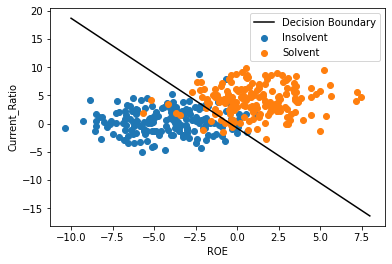

## V. Using the model

Now suppose you wish to predict whether a particular firm which has an ROE of 0.0 and a current ratio of 0.0 is more likely or not to be insolvent. According to your model, what is the probability that it is insolvent?

Complete the following function to compute an answer. Your one line of code should be of the form

```
prob = ---(---(---, ---))
```

If implemented correctly, For ROE of 0.0, Current ratio of 0.0, and parameters `theta_opt` that you have already calculated using `fmin_bfgs` with respect to your features $X$ and correct labels $y$, the probability of insolvency for such a firm should be approximately $0.4$.

**Hint:** The function templates you have worked up until now have used the same variable names as global variables that you have been using, but this convention is about to change. This convention was helpful to get us started to see how these various pieces are put together. But, unfortunately, this convention comes with a cost, since our functions are general: they do not and **should not hard-code variables** from outside the function call. For example, **costFunction(theta, X, y)** takes as arguments three **variables**. In practice, you can call **costFunction(duck, Xman, why)**, where 'duck' is substituted inside the function for 'theta', 'Xman' for 'X', and 'why' for 'y'. Assuming these variables are of the right type, the algorithm will run. A mistake that can happen is to hard code our X into a function, rather than using whatever is called in the X position. This might not make sense until you run into an error. However, you may run into an error involving **theta** now that we have computed **theta_opt**.

**Student's answer(Top)**

```python
def probabilityInsolvent(score1, score2, theta):
    """
        probabilityInsolvent calculates the probability that a
        firm is insolvent based on two indicators:

          score1, which in our model is the ROE score;
          score2, which in our model is the Current Ratio;

        according to the logistic regression model parameterized by

          theta, the fitted parameter vector

        and the features matrix X and labeled category vector y.

    """
    #construct a 1 x 2 array from score1 and score2
    scores = np.array([score1, score2])

    # add a 1 to the front of scores, yielding
    # a 1 x 3 array
    scores = np.hstack((np.array([1]), scores))

    # calculate the probability (1 line)
    # prob = ---
    #
    prob = sigmoid(scores.dot(theta))
    return prob
```

```python
# Compute the probability of insolvency
probabilityInsolvent(0.0, 0.0, theta_opt)
```

```
0.3971584898269462
```

**Grade cell: `probOfAcceptance-test` Score: 0.5 / 0.5 (Top)**

```python
# Test Cell
### BEGIN HIDDEN TESTS
test_theta_new = np.array([-0.161, -1.033, -0.780])
assert round(probabilityInsolvent(0.0, 0.0, test_theta_new),7) == 0.4598367
### END HIDDEN TESTS
```

## VI. Evaluating the model

We can see from the plot of the decision boundary that our model is not completely accurate: there are some firms that we know are insolvent but which the model predicts are solvent and vice versa. But how accurate is the model overall?

To answer this question, we first define a `predictionAccuracy` function to predict values of $y$ given the values computed for $h(x; \boldsymbol{\theta})$ by our logistic regression model. This is done for you in the next cell.

```python
# Evaluate the Accuracy of your Model
# DO NOT EDIT
def predictAccuracy(X, y, theta):
    pred = [sigmoid(np.dot(X, theta)) >= 0.5]
    acc = np.mean(pred == y)
    return acc
```

The next cell applies `predictAccuracy` (in hidden tests) to evaluate the accuracy of your optimized logistic regression model on the training data. If implemented correctly, your training accuracy should be approximately $0.918$.

**Grade cell: `training_accuracy_test` Score: 0.5 / 0.5 (Top)**

```python
# Test Cell
### BEGIN HIDDEN TESTS
assert len(theta_opt) == 3
assert round(predictAccuracy(X, y.flatten(), theta_opt),8) == 0.91784703
### END HIDDEN TESTS
```

## VII. Changing the decision threshold

The decision boundary we plotted above and the probabilities that we calculated for insolvency ($y = 1$) where keyed to a probability **threshold** of 1/2. Recall that this threshold corresponds to when $z = 0$ for `sigmoid(z)`, which yields the probability $p(y =1) = g(0) = \frac{1}{2}$.

The next graph depicts a $g(z) = \frac{1}{2}$ threshold as a function of $z =0$, plotted in red. Recall that negative values of $z$ correspond to probability estimates that the negative ($ y = 0$) class is more likely than the than positive class $(y = 1$), positive values of $z$ correspond to estimates that the positive class ($y =1$) is more likely than the negative class ($y = 0$), and $z=0$, the corner case of even-odds that the class is positive or negative, is by convention included with the more-likely-than-not predictions that the class is positive ($y =1$).

[figure not shown]

Suppose we wish to have a higher probability of acceptance than 1/2, specifically $p(y =1) = 0.7$. As a function of $z$, this would entail moving the threshold to the right:

[figure not shown]

Your next task is to (i) find $z$ such that $p(y =1) = 0.7$ and (ii) plot a **new decision boundary** with respect to that new probability threshold.

### Step 1. New Decision Boundary

Use the next cell to compute and plot a new decision boundary where $p(y =1) = 0.7$ rather than $p(y = 1) = 0.5$. Your plot should include the original decision boundary as a dashed line. Be careful not to mix them up!

**Student's answer Score: 0.75 / 1.0 (Top)**

```python
z = np.log(3 / 7)
plot_x = [-10, 8]
plot_y = -1/theta_opt[2]*(theta_opt[0]
          + np.dot(theta_opt[1],plot_x))

plot_y_new = -1/theta_opt[2]*(z + theta_opt[0]
             + np.dot(theta_opt[1],plot_x))

mask = y.flatten() == 1
insolv = plt.scatter(X[mask][:,1], X[mask][:,2], label='Insolvent')
solv = plt.scatter(X[~mask][:,1], X[~mask][:,2], label='Solvent')
boundary = plt.plot(plot_x, plot_y, linestyle='--', label='Decision Boundary', color='black')
boundary_new = plt.plot(plot_x, plot_y_new, label='New Decision Boundary', color='black')
plt.legend(loc='best')
plt.ylabel('Current_Ratio')
plt.xlabel('ROE')
plt.show()
```

**Comments:**

Current_Ratio scale is (2x) but should not be.

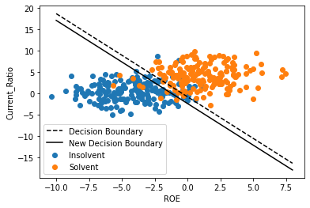

### Step 2. New Predicted Probability of Insolvency

Our accuracy score is approximately $0.918$. Can we get a higher accuracy score? This is the question we will explore next.

There are two functions to finish: (i) `newPredictAccuracy()` computes the accuracy of your model with a given threshold probability value specified by `threshold`; (ii) `maxAcc()` finds the threshold value or values which maximizes the accuracy score computed by `newPredictAccuracy()` and returns two variables: `acc`, which stores the highest accuracy score, and `thresh`, which stores the threshold value or values in an np.array for that highest score.

To simplify computations and standardize answers, the **precision criterion** of tested threshold values is **two decimal places**. For example, given the closed interval $[0.49, 0.51]$ the sequence of admissible threshold values you could use is $(0.49, 0.50, 0.51)$. No other number within $[0.49, 0.51]$ would satisfy the precision criterion.

**Student's answer(Top)**

```python
## complete the function
def newPredictAccuracy(X, y, theta, threshold=0.5):
    pred = [sigmoid(np.dot(X, theta)) >= threshold]
    acc = np.mean(pred == y)
    return acc
```

**Grade cell: `new_predict_acc-test` Score: 0.5 / 0.5 (Top)**

```python
# Test Cell
### BEGIN HIDDEN TESTS
assert round(newPredictAccuracy(X, y, theta_opt, threshold=0.7),7) == 0.9036827
### END HIDDEN TESTS
```

**Student's answer(Top)**

```python
## complete the function
def maxAcc(X,y,theta):
    threshes = np.arange(0, 1, 0.01)
    acc = 0
    thresh = []

    for t in threshes:
        curr_acc = newPredictAccuracy(X, y, theta, t)
        if curr_acc == acc:
            thresh.append(round(t, 2))
        elif curr_acc > acc:
            thresh = [round(t, 2)]
            acc = curr_acc
    thresh = np.asarray(thresh)
    return acc, thresh
```

**Grade cell: `maxAcc-test-1` Score: 0.5 / 0.5 (Top)**

```python
# Test Cell
### BEGIN HIDDEN TESTS
test = maxAcc(X,y,theta_opt)
assert round(test[0],9) == 0.92917847
del test
### END HIDDEN TESTS
```

**Grade cell: `maxAcc-test-2` Score: 0.5 / 0.5 (Top)**

```python
# Test Cell
### BEGIN HIDDEN TESTS
test = maxAcc(X,y,theta_opt)
if type(test[1]) == tuple and type(test[1][0]) == np.ndarray:
    test = test[1][0]
if type(test[1]) == np.ndarray:
    test = test[1]
#else:
   # raise ValueError("Unexpected datatype for indx.")
assert len(test) == 3
del test
### END HIDDEN TESTS
```

**Grade cell: `maxAcc-test-3` Score: 0.5 / 0.5 (Top)**

```python
# Test Cell
### BEGIN HIDDEN TESTS
test = maxAcc(X,y,theta_opt)
if type(test[1]) == tuple and type(test[1][0]) == np.ndarray:
    test = test[1][0]
if type(test[1]) == np.ndarray:
    test = test[1]
#else:
   # raise ValueError("Unexpected datatype for indx.")
assert round(test[0], 2) == 0.41 and round(test[1], 2) == 0.42 and round(test[2], 2) == 0.43
del test
### END HIDDEN TESTS
```

# PART B - SciKit-Learn Logistic Regression

Naturally, there are built-in libraries for logistic regression classification models. In fact, it just takes a few lines of code once we import `LogisticRegression` from the `linear_model` methods in the `sklearn` (scikit-learn) library.

```python
from sklearn.linear_model import LogisticRegression
```

Sklearn uses a common [API](https://en.wikipedia.org/wiki/Application_programming_interface) for building models. So, the sequence we follow to build a simple linear model resembles the sequence of steps for building a wide range of models. It is good, therefore, to become aquainted with this tool.

Basically, there are two steps:

- Instantiate a model
- Fit the model

Followed by plotting and some rudimentary anlysis of the model. Later in the course we will add a third step, which involves making predictions and evaluating the accuracy of those predictions.

## Question 3

To answer the next question, you should use a [Sklearn logistic regression](https://scikit-learn.org/stable/modules/generated/sklearn.linear_model.LogisticRegression.html) model and methods. It is necessary to use the following (and **only** the following) parameter settings:

```
model = LogisticRegression(random_state=45)
```

There are three quantities that you will need to report about your Logistic regression model:

- a) The predicted probability that $y=0$ for the first observation in the training set.
- b) The smallest predicted probability of all observations predicted to belong to the positive class.
- c) True or False: the predicted class label of the last observation in the training set is correct.

Note that the precision at which your answers will be checked is unknown to you, meaning that you will need to compute the numerical quantities within the next `ans_` function. Pay attention to the data types of each parameter.

### Q3 Answer:

**Student's answer(Top)**

```python
def ans_three():
    """ Returns four numerical values of your linear model.

    Parameters
    ----------
    :a:  float
        The predicted probability that y = 0 for the first training example.
    :b:  float
        The smallest predicted probability of all predicted positive class labels
    :c:  Boolean
        The truth value of the assertion that the predicted label of the last observation is correct.

    Returns
    -------
    :a:
    :b:
    :c:
    """
    # Reload X, y
    # Assumes df is declared.
    X, y = array_maker(df)

    model = LogisticRegression(random_state=45).fit(X, y)

    X_predict = model.predict_proba(X)
    a = float(X_predict[0,0])
    b = float(min(X_predict[:,1][model.predict(X) == 1]))
    c = model.predict(X)[-1] == y[-1]

    return a, b, c # do not edit
```

**Grade cell: `Question-3-test1` Score: 0.75 / 0.75 (Top)**

```python
# Test Cell
### BEGIN HIDDEN TESTS
aa, bb, cc = ans_three()
print(f'Your answers to Question 3:\n a = {aa}\n b = {bb}\n c = {cc}\n')
#
data = df.values
yy = data[:,-1]
XX = np.delete(data,-1,1)
#
lr = LogisticRegression(random_state=45)
# fit the model
lr.fit(XX, yy)
# Predicted Classes
X_pred = lr.predict(XX)
# Predicted Probabilities
X_prob = lr.predict_proba(XX)

a_ans = lr.predict_proba(XX)[0][0]
b_ans = np.ma.masked_where(X_pred == 0, X_prob[:,1]).min()
#
print(f'Correct answers to Question 3:\n a = {a_ans}\n b = {b_ans}\n c = {False}')
#
if round(aa, 9) == round(a_ans, 9):
    assert True
else: raise AssertionError("See Answer Key:\n Remember the Python is 0-indexed.")
del aa
del bb
del cc

del yy
del XX

### END HIDDEN TESTS
```

```
Your answers to Question 3:
 a = 0.62626867441294
 b = 0.5041961265605899
 c = False

Correct answers to Question 3:
 a = 0.62626867441294
 b = 0.5041961265605899
 c = False
```

**Grade cell: `cell-6fd340c7ecf36e8a` Score: 0.75 / 0.75 (Top)**

```python
# Test Cell
### BEGIN HIDDEN TESTS
aa, bb, cc = ans_three()
if round(bb, 9) == round(b_ans, 9):
    assert True
else: raise AssertionError("See Answer Key")
del aa
del bb
del cc
### END HIDDEN TESTS
```

**Grade cell: `cell-98483df44ebaa642` Score: 0.5 / 0.5 (Top)**

```python
# Test Cell
### BEGIN HIDDEN TESTS
aa, bb, cc = ans_three()
if cc == False:
    assert True
else: raise AssertionError("Answer Key:\nc) The predicted class label is 1.0 but the true label is 0.0.\n   Note that the datatype of c is a Boolean. So, the correct answer is: False.")
del aa
del bb
del cc

del a_ans
del b_ans
del lr
### END HIDDEN TESTS
```

**Grade cell: `cell-5425d410332fcbb9` Score: 0.0 / 0.0 (Top)**

```python
# Test for Collaborator policy before submission
%run -i 'collaboration_test.py'
```

Before submitting this notebook, you should do the following steps:

1. **Restart Kernel** (Kernel ⟶ Restart and Clear Output)
2. **Run all Cells** (Cell ⟶ Run All)
3. **Validate Notebook**: Press the 'Validate' button on this page. This is the first validation step.
4. **Save File** (File ⟶ Save and Checkpoint)
5. **Close and Shutdown Kernel** (File ⟶ Close and Halt)

Then, follow the final steps for submitting the assignment.

1. **Validate Submission**: On the submissions page, validate your assignment folder ps1. This is the second validation step. Your submissions is ready for submission only if it passes both the first and second validation steps.
2. **Submit**: Press the submission button to submit your validated assignment. The time stamp is the time of submission.